# Base Ball

```r
library(ggplot2)
library(dbplyr)
```

```r
library(Lahman)
data("Teams")
head(Teams)
```

```
##   yearID lgID teamID franchID divID Rank  G Ghome  W  L DivWin WCWin LgWin
## 1   1871   NA    BS1      BNA  <NA>    3 31    NA 20 10   <NA>  <NA>     N
## 2   1871   NA    CH1      CNA  <NA>    2 28    NA 19  9   <NA>  <NA>     N
## 3   1871   NA    CL1      CFC  <NA>    8 29    NA 10 19   <NA>  <NA>     N
## 4   1871   NA    FW1      KEK  <NA>    7 19    NA  7 12   <NA>  <NA>     N
## 5   1871   NA    NY2      NNA  <NA>    5 33    NA 16 17   <NA>  <NA>     N
## 6   1871   NA    PH1      PNA  <NA>    1 28    NA 21  7   <NA>  <NA>     Y
##   WSWin   R   AB   H X2B X3B HR BB SO SB CS HBP SF  RA  ER  ERA CG SHO SV
## 1  <NA> 401 1372 426  70  37  3 60 19 73 NA  NA NA 303 109 3.55 22   1  3
## 2  <NA> 302 1196 323  52  21 10 60 22 69 NA  NA NA 241  77 2.76 25   0  1
## 3  <NA> 249 1186 328  35  40  7 26 25 18 NA  NA NA 341 116 4.11 23   0  0
## 4  <NA> 137  746 178  19   8  2 33  9 16 NA  NA NA 243  97 5.17 19   1  0
## 5  <NA> 302 1404 403  43  21  1 33 15 46 NA  NA NA 313 121 3.72 32   1  0
## 6  <NA> 376 1281 410  66  27  9 46 23 56 NA  NA NA 266 137 4.95 27   0  0
##   IPouts  HA HRA BBA SOA   E DP    FP                    name
```

[output cut: 20 more lines]

```r
colnames(Teams)
```

```
##  [1] "yearID"         "lgID"           "teamID"         "franchID"
##  [5] "divID"          "Rank"           "G"              "Ghome"
##  [9] "W"              "L"              "DivWin"         "WCWin"
## [13] "LgWin"          "WSWin"          "R"              "AB"
## [17] "H"              "X2B"            "X3B"            "HR"
## [21] "BB"             "SO"             "SB"             "CS"
## [25] "HBP"            "SF"             "RA"             "ER"
## [29] "ERA"            "CG"             "SHO"            "SV"
## [33] "IPouts"         "HA"             "HRA"            "BBA"
## [37] "SOA"            "E"              "DP"             "FP"
## [41] "name"           "park"           "attendance"     "BPF"
## [45] "PPF"            "teamIDBR"       "teamIDlahman45" "teamIDretro"
```

Plots of Runs per game Vs home runs per game

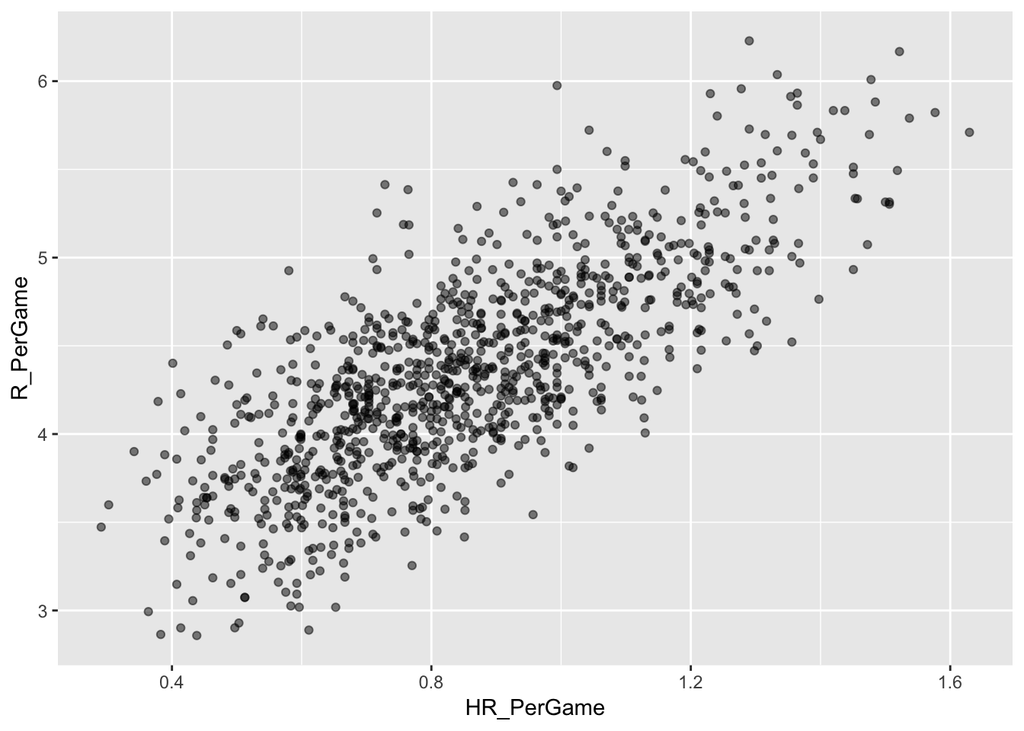

```r
require(dplyr)
require(ggplot2)
Teams %>%
  filter(yearID %in% 1961:2001)%>%
  mutate(HR_PerGame = HR/G, R_PerGame=R/G) %>%
  ggplot(aes(HR_PerGame,R_PerGame)) +
  geom_point(alpha = 0.5)
```

Here’s a plot of runs per game versus home runs per game. The plot shows a very strong association– teams with more home runs tended to score more runs.

Now, let’s examine the relationship between stolen bases and wins. Here are the runs per game plotted against stolen bases per game.

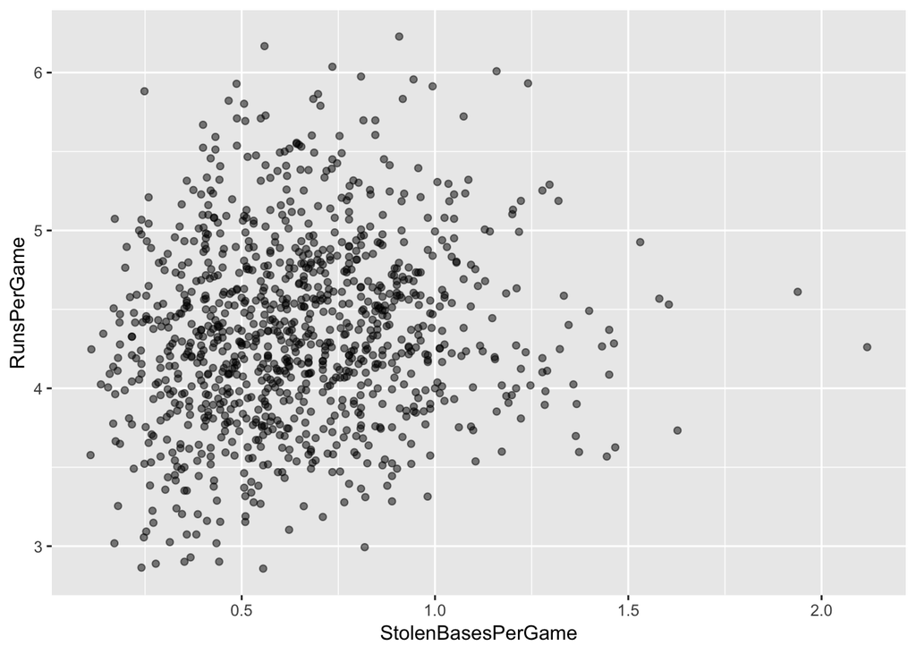

```r
Teams %>%
  filter(yearID %in% 1961:2001) %>%
  mutate(StolenBasesPerGame = SB/G,RunsPerGame = R/G) %>%
  ggplot(aes(StolenBasesPerGame,RunsPerGame))+
  geom_point(alpha =0.5)
```

Here, the relationship is not as clear.

Finally, let’s examine the relationship between bases on balls and runs. Here are runs per game versus bases on balls per game.

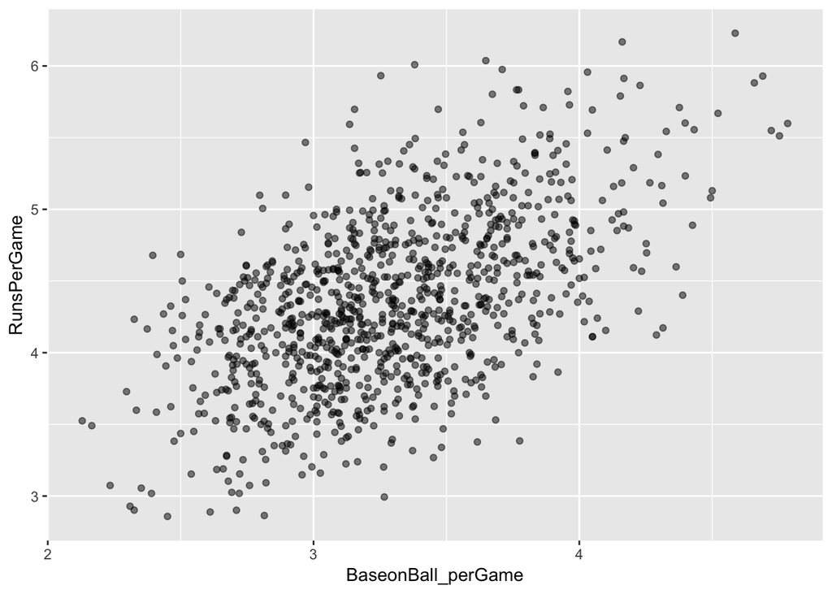

```r
Teams %>%
  filter(yearID %in% 1961:2001) %>%
  mutate(BaseonBall_perGame = BB/G, RunsPerGame = R/G)%>%
  ggplot(aes(BaseonBall_perGame,RunsPerGame))+
  geom_point(alpha = 0.5)
```

Although the relationship is not as strong as it was for home runs, we do see a pretty strong relationship here. We know that, by definition, home runs cause runs, because when you hit a home run, at least one run will score. Now it could be that home runs also cause the bases on balls. If you understand the game, you will agree with me that that could be the case. So it might appear that a base on ball is causing runs, when in fact, it’s home runs that’s causing both. This is called confounding.

```r
Teams %>%
  filter(yearID %in% 1961:2001) %>%
  mutate(singles = (H-HR-X2B-X3B)/G,BB=BB/G,HR= HR/G) %>%
  summarise(cor(BB,HR),cor(singles,HR),cor(BB,singles))
```

```
##   cor(BB, HR) cor(singles, HR) cor(BB, singles)
## 1   0.4039125       -0.1738404      -0.05605071
```

We see that the correlation between bases on balls and homeruns is quite high compared to the other two pairs. It turns out that pitchers, afraid of homeruns, will sometimes avoid throwing strikes to homerun hitters. As a result, homerun hitters tend to have more bases on balls. Thus, a team with many homeruns will also have more bases on balls than average, and as a result, it may appear that bases on balls cause runs. But it is actually the homeruns that caused the runs. In this case, we say that bases on balls are confounded with homeruns. But could it be that bases on balls still help? To find out, we somehow have to adjust for the homerun effect.

To try to determine if bases on balls is still useful for creating runs, a first approach is to keep home runs fixed at a certain value and then examine the relationship between runs and bases on balls. As we did when we stratified fathers by rounding to the closest inch, here, we can stratify home runs per game to the closest 10th. We filtered our strata with few points.

```r
dat <- Teams %>% filter(yearID %in% 1961:2001) %>%
  mutate(HR_strata = round(HR/G,1),
         BB_per_game = BB/G,
         R_per_game = R/G) %>%
  filter(HR_strata >=0.4 & HR_strata <=1.2)
```

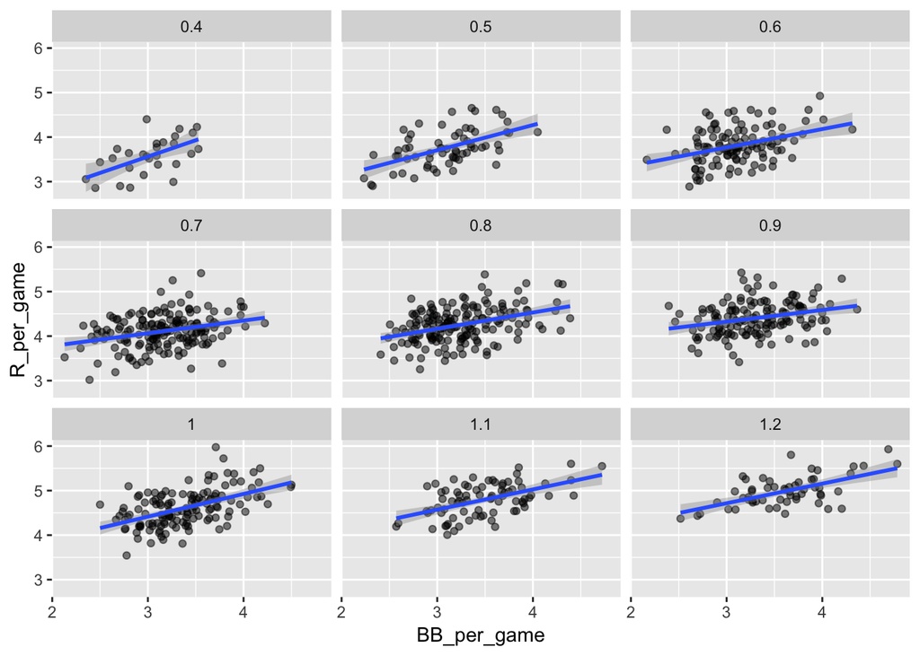

```r
dat %>%
  ggplot(aes(BB_per_game,R_per_game))+
  geom_point(alpha= 0.5)+
  geom_smooth(method = "lm")+
   facet_wrap(~HR_strata)
```

Remember that the regression slope for predicting runs with bases on balls when we ignore home runs was 0.735. But once we stratify by home runs, these slopes are substantially reduced. We can actually see what the slopes are by using this code. We stratify by home run and then compute the slope using the formula that we showed you previously. These values are closer to the slope we obtained from singles, which is 0.449.

```r
dat %>%
  group_by(HR_strata) %>%
  summarise(slope = cor(BB_per_game,R_per_game) * sd(R_per_game)/sd(BB_per_game))
```

```
## # A tibble: 9 x 2
##   HR_strata slope
##       <dbl> <dbl>
## 1       0.4 0.734
## 2       0.5 0.566
## 3       0.6 0.412
## 4       0.7 0.285
## 5       0.8 0.365
## 6       0.9 0.261
## 7       1   0.511
## 8       1.1 0.454
## 9       1.2 0.440
```

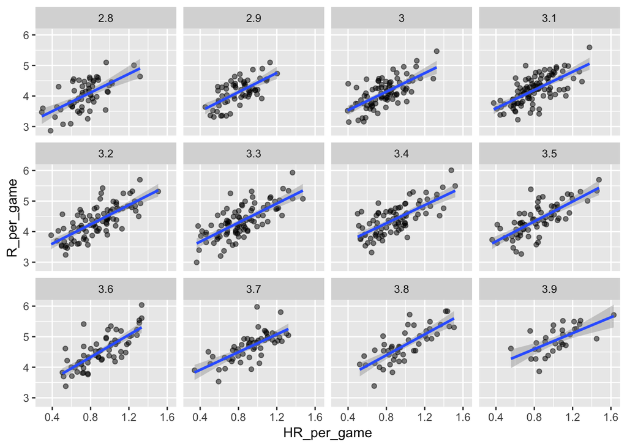

```r
dat <- Teams %>% filter(yearID  %in% 1961:2001) %>%
  mutate(BB_strata = round(BB/G,1),
         HR_per_game = HR/G,
         R_per_game = R/G) %>%
  filter(BB_strata >= 2.8 & BB_strata <=3.9)

dat %>%
  ggplot(aes(HR_per_game,R_per_game))+
  geom_point(alpha=0.5)+
  geom_smooth(method="lm")+
  facet_wrap(~BB_strata)
```

```r
dat %>%
  group_by(BB_strata) %>%
  summarise(slope = cor(HR_per_game,R_per_game) * sd(R_per_game)/sd(HR_per_game))
```

```
## # A tibble: 12 x 2
##    BB_strata slope
##        <dbl> <dbl>
##  1       2.8  1.53
##  2       2.9  1.57
##  3       3    1.52
##  4       3.1  1.49
##  5       3.2  1.58
##  6       3.3  1.56
##  7       3.4  1.48
##  8       3.5  1.63
##  9       3.6  1.83
## 10       3.7  1.45
## 11       3.8  1.70
## 12       3.9  1.30
```

In this case, the slopes are the following. You can see they are all around 1.5, 1.6, 1.7. So they do not change that much from the original slope estimate, which was 1.84. Regardless, it seems that if we stratify by home runs, we have an approximately bivariate normal distribution

```r
dat %>%
  group_by(HR) %>%
  do(fit = lm(R~BB,data = .))
```

```
## Source: local data frame [174 x 2]
## Groups: <by row>
##
## # A tibble: 174 x 2
##       HR fit
##  * <int> <list>
##  1    32 <S3: lm>
##  2    39 <S3: lm>
##  3    45 <S3: lm>
##  4    49 <S3: lm>
##  5    50 <S3: lm>
##  6    55 <S3: lm>
##  7    56 <S3: lm>
##  8    57 <S3: lm>
##  9    58 <S3: lm>
## 10    61 <S3: lm>
## # ... with 164 more rows
```

```r
get_lse <- function(data){
  fit <- lm(R ~ BB, data = data)
  data.frame(term = names(fit$coefficients),
             slope = fit$coefficients,
             se = summary(fit)$coefficient[,2])
}
  dat %>%
    group_by(HR) %>%
    do(get_lse(.))
```

```
## # A tibble: 348 x 4
## # Groups:   HR [174]
##       HR term          slope    se
##    <int> <fct>         <dbl> <dbl>
##  1    32 (Intercept) 382       NaN
##  2    32 BB           NA       NaN
##  3    39 (Intercept) 431       NaN
##  4    39 BB           NA       NaN
##  5    45 (Intercept) 394       NaN
##  6    45 BB           NA       NaN
##  7    49 (Intercept) 219.      NaN
##  8    49 BB            0.789   NaN
##  9    50 (Intercept) 464       NaN
## 10    50 BB           NA       NaN
## # ... with 338 more rows
```

```r
library(broom)
dat %>%
  group_by(lgID) %>%
  do(tidy(lm(R ~ HR, data = .), conf.int = T)) %>%
  filter(term == "HR")
```

```
## # A tibble: 2 x 8
## # Groups:   lgID [2]
##   lgID  term  estimate std.error statistic  p.value conf.low conf.high
##   <fct> <chr>    <dbl>     <dbl>     <dbl>    <dbl>    <dbl>     <dbl>
## 1 AL    HR        1.90    0.0871      21.8 8.64e-72     1.73      2.07
## 2 NL    HR        1.91    0.0791      24.1 5.30e-80     1.75      2.06
```

```r
dat %>%
  group_by(lgID) %>%
  do(glance(lm(R ~ HR, data = .)))
```

```
## # A tibble: 2 x 12
## # Groups:   lgID [2]
##   lgID  r.squared adj.r.squared sigma statistic  p.value    df logLik   AIC
##   <fct>     <dbl>         <dbl> <dbl>     <dbl>    <dbl> <int>  <dbl> <dbl>
## 1 AL        0.523         0.522  69.1      476. 8.64e-72     2 -2464. 4934.
## 2 NL        0.592         0.591  59.4      581. 5.30e-80     2 -2217. 4440.
## # ... with 3 more variables: BIC <dbl>, deviance <dbl>, df.residual <int>
```

```r
dat %>%
  do(tidy(lm(R ~ HR, data = .), conf.int = T)) %>%
  filter(term == "HR")
```

```
## # A tibble: 1 x 7
##   term  estimate std.error statistic   p.value conf.low conf.high
##   <chr>    <dbl>     <dbl>     <dbl>     <dbl>    <dbl>     <dbl>
## 1 HR        1.91    0.0581      32.8 1.42e-152     1.79      2.02
```

```r
dat <- Teams %>% filter(yearID %in% 1961:2001) %>%
  mutate(HR = HR/G,
         R = R/G) %>%
  select(lgID, HR, BB, R)
dat %>%
  group_by(lgID) %>%
  do(mod = lm(R ~ HR, data = .))
```

```
## Source: local data frame [2 x 2]
## Groups: <by row>
##
## # A tibble: 2 x 2
##   lgID  mod
## * <fct> <list>
## 1 AL    <S3: lm>
## 2 NL    <S3: lm>
```

```r
fit <- Teams %>%
  filter(yearID %in% 1961:2001) %>%
  mutate(BB = BB/G,HR = HR/G, R = R/G) %>%
  lm(R ~ BB+HR,data = .)

tidy(fit,conf.int = TRUE)
```

```
## # A tibble: 3 x 7
##   term        estimate std.error statistic   p.value conf.low conf.high
##   <chr>          <dbl>     <dbl>     <dbl>     <dbl>    <dbl>     <dbl>
## 1 (Intercept)    1.74     0.0823      21.2 7.30e- 83    1.58      1.91
## 2 BB             0.387    0.0270      14.3 1.20e- 42    0.334     0.440
## 3 HR             1.56     0.0490      31.9 1.75e-155    1.47      1.66
```

data exploration let us to this model. Here, the data is approximately normal. And conditional distributions were also normal. Thus, we’re justified to pose a linear model like this. With yi, the runs per game. x1, walks per game. And x2, home runs per game. To we used linear model with 2 variables, Here’s model that fits tour multiple regression model.

Now, we can use the tidy function to see the nice summary. When we fit the model with only one variable without the adjustment, the estimated slopes were 0.735 and 1.844 for bases on ball and home runs, respectively. But note that when we fit the multivariate model, both these slopes go down with the bases on ball effect decreasing much more.

```r
fit <- Teams %>%
  filter(yearID %in% 1961:2001) %>%
  mutate(BB = BB/G,
         singles = (H-X2B-X3B-HR)/G,
         doubles = X2B/G,
         triples = X3B/G,
         HR= HR/G,
         R = R/G) %>%
  lm(R~BB+singles+doubles+triples+HR, data = .)
coefs <- tidy(fit,conf.int = TRUE)
coefs
```

```
## # A tibble: 6 x 7
##   term        estimate std.error statistic   p.value conf.low conf.high
##   <chr>          <dbl>     <dbl>     <dbl>     <dbl>    <dbl>     <dbl>
## 1 (Intercept)   -2.77     0.0862     -32.1 5.32e-157   -2.94     -2.60
## 2 BB             0.371    0.0117      31.6 2.08e-153    0.348     0.394
## 3 singles        0.519    0.0127      40.8 9.81e-217    0.494     0.544
## 4 doubles        0.771    0.0226      34.1 8.93e-171    0.727     0.816
## 5 triples        1.24     0.0768      16.1 2.24e- 52    1.09      1.39
## 6 HR             1.44     0.0244      59.3 0.           1.40      1.49
```

```r
Teams %>%
  filter(yearID %in% 1961:2001) %>%
  mutate(BB = BB/G,
         singles = (H-X2B-X3B-HR)/G,
         doubles = X2B/G,
         triples = X3B/G,
         HR= HR/G,
         R = R/G) %>%
  mutate(R_hat = predict(fit,newdata = .))
```

[output not shown]

[output cut: 6147 more lines]

```r
data("Batting")
pa_per_game <- Batting %>%
  filter(yearID==2002) %>%
  group_by(teamID) %>%
  summarize(pa_per_game = sum(AB+BB)/max(G)) %>%
  .$pa_per_game %>%
  mean
```

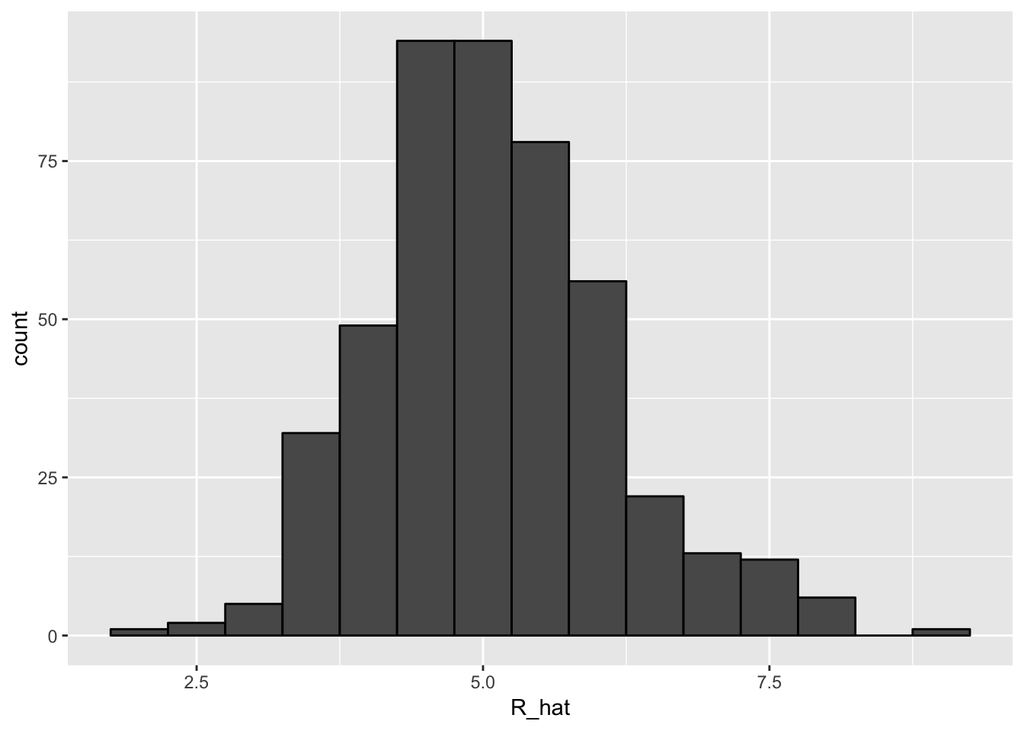

```r
players <- Batting %>% filter(yearID %in% 1999:2001) %>%
  group_by(playerID) %>%
  mutate(PA = BB+AB) %>%
  summarize(G = sum(PA)/pa_per_game,
            BB = sum(BB)/G,
            singles = sum(H-X2B-X3B-HR)/G,
            doubles = sum(X2B)/G,
            triples = sum(X3B)/G,
            HR = sum(HR/G),
            AVG = sum(H)/sum(AB),
            PA = sum(PA)) %>%
  filter(PA>=300) %>%
  select(-G) %>%
  mutate(R_hat = predict(fit,newdata = .))

players %>% ggplot(aes(R_hat))+
  geom_histogram(binwidth = 0.5,color = "black")
```